# IODS course project

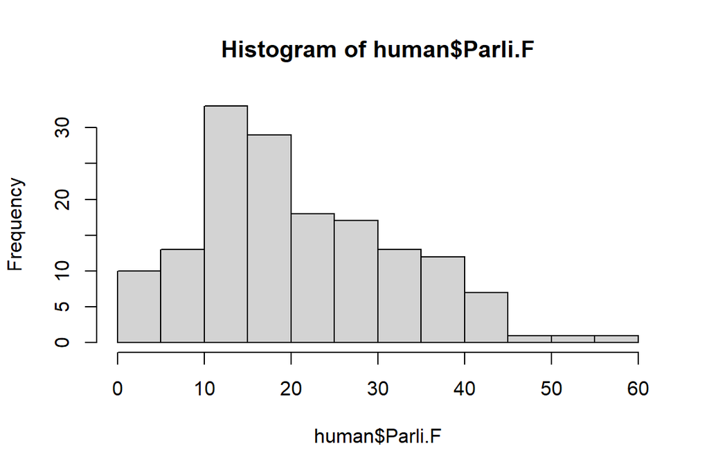

```r
hist(human$Parli.F)
```

```r
# Moving the country names to rownames
library(tibble)
human_ <- column_to_rownames(human, "Country")
#human_ # Remove the # to view
# Visualize all the human_ variables
library(GGally)
```

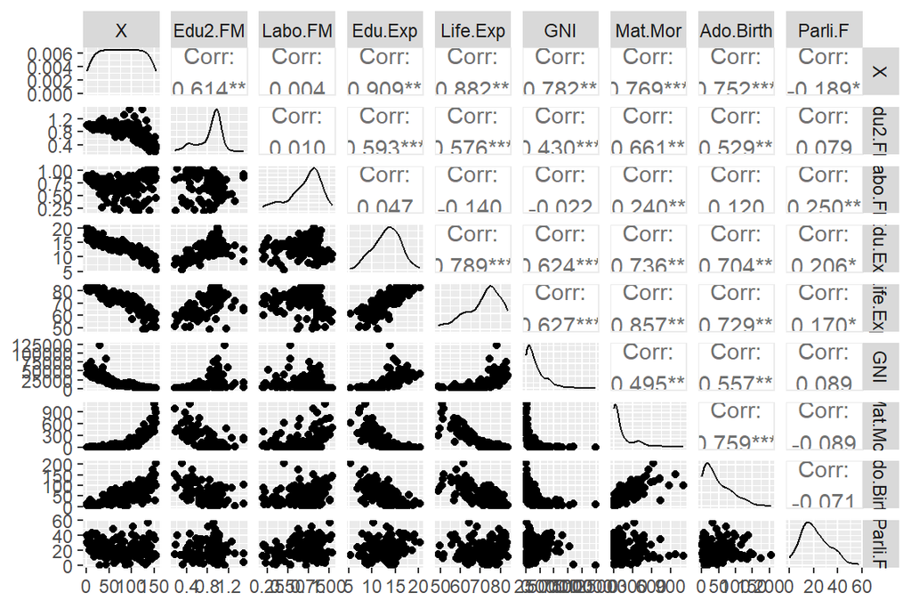

```r
ggpairs(human_ , progress=F)
```

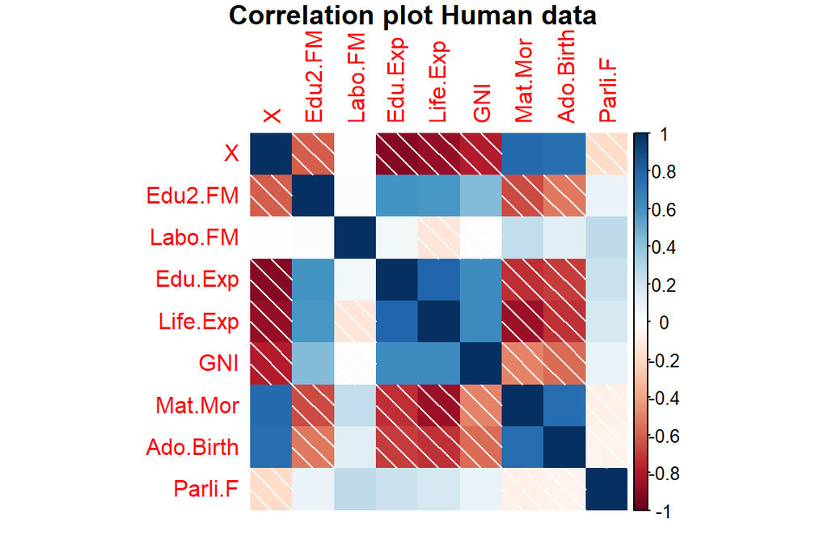

```r
# create the correlation matrix, round it to two digits
cor_matrix <- round(cor(human_),2)
# Let's visualize it
library(corrplot)
corrplot(cor_matrix, method="shade", title = "Correlation plot Human data", mar=c(1,1,1,1))
```

Many interesting observations can be made from the data. A few variables to note is that the percentage of female representatives in the parliament, `Parli.F` , is most commonly 10 to 20 percent, and only below 5 countries make it to an equal representation. From adolescent birth rate `Ado.Birth` and maternal mortality ratio `Mat.Mor` it can be seen that in the vast majority of countries, very few adolescents give to birth and mothers die in labor - this is an excellent development although there still are problems in some countries.

From the correlation matrix it can be seen that two variable pairs show a quite strong positive correlation: `Life.Exp` and `Edu.Exp` and `Ado.Birth` and `Mat.Mor`. In countries with longer life expectancy, people also educate themselves further, and in countries where adolescents give to birth, more mothers also die in labor. These correlations show that in well-faring countries people live longer and educate themselves more, whereas in some poorer developing countries with worse situation in gender equality women get pregnant rather young and lack access to medical treatment when giving birth.

*Perform principal component analysis (PCA) on the raw (non-standardized) human data. Show the variability captured by the principal components. Draw a biplot displaying the observations by the first two principal components (PC1 coordinate in x-axis, PC2 coordinate in y-axis), along with arrows representing the original variables. (0-2 points)*

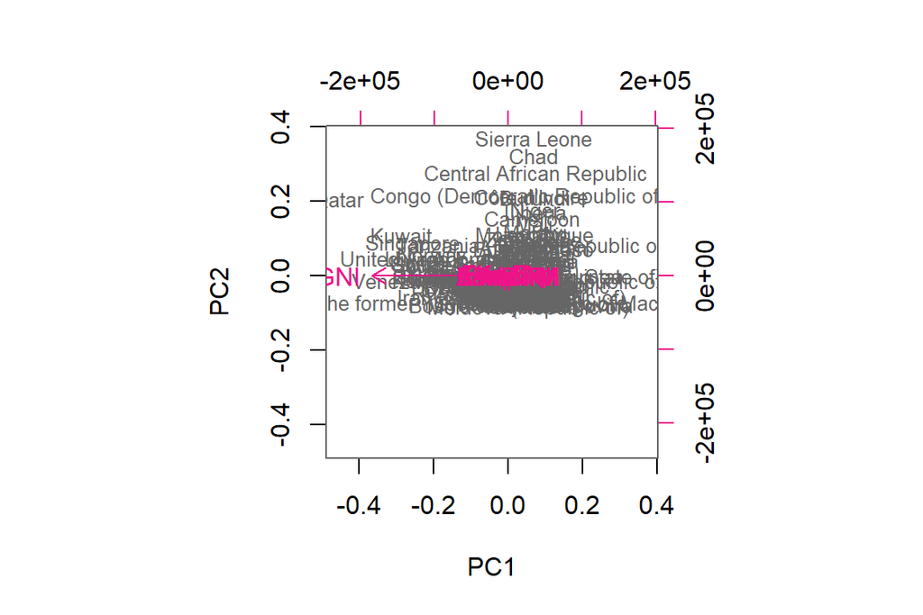

```r
# perform principal component analysis with un-standardized data
pca_human <- prcomp(human_)

# draw a biplot of the principal component representation and the original variables
biplot(pca_human, cex = c(0.8, 1), col = c("grey40", "deeppink2"))
```

```r
# summary of the pca
summary(pca_human)
```

```
## Importance of components:
##                              PC1      PC2   PC3   PC4   PC5   PC6   PC7    PC8
## Standard deviation     1.854e+04 186.5901 26.22 18.72 10.95 3.137 1.078 0.1888
## Proportion of Variance 9.999e-01   0.0001  0.00  0.00  0.00 0.000 0.000 0.0000
## Cumulative Proportion  9.999e-01   1.0000  1.00  1.00  1.00 1.000 1.000 1.0000
##                           PC9
## Standard deviation     0.1591
## Proportion of Variance 0.0000
## Cumulative Proportion  1.0000
```

Hmm, based on this analysis, the Gross National Income is the only variable explaining variation in the data. Also the summary shows large standard deviations, which is a sign of the model not explaining the data very well. This is sure due to the data not being standardised, so let’s try that next.

*Standardize the variables in the human data and repeat the above analysis. Interpret the results of both analysis (with and without standardizing). Are the results different? Why or why not? Include captions (brief descriptions) in your plots where you describe the results by using not just your variable names, but the actual phenomena they relate to. (0-4 points)*

```r
# standardize the variables
human_std <- scale(human_)
# perform principal component analysis (with the SVD method)
pca_human <- prcomp(human_std)

# a summary of pca_human
s <- summary(pca_human)
s
```

```
## Importance of components:
##                           PC1    PC2     PC3     PC4     PC5    PC6     PC7
## Standard deviation     2.2770 1.1437 0.87751 0.79700 0.66196 0.5482 0.46456
## Proportion of Variance 0.5761 0.1453 0.08556 0.07058 0.04869 0.0334 0.02398
## Cumulative Proportion  0.5761 0.7214 0.80698 0.87756 0.92624 0.9596 0.98362
##                            PC8     PC9
## Standard deviation     0.32938 0.19731
## Proportion of Variance 0.01205 0.00433
## Cumulative Proportion  0.99567 1.00000
```

```r
# rounded percentanges of variance captured by each PC
pca_pr <- round(1*s$importance[2, ], digits = 5)
pca_pr
```

```
##     PC1     PC2     PC3     PC4     PC5     PC6     PC7     PC8     PC9
## 0.57608 0.14534 0.08556 0.07058 0.04869 0.03340 0.02398 0.01205 0.00433
```

[figure not shown]

```r
# create object pc_lab to be used as axis labels
pc_lab <- paste0(names(pca_pr), " (", pca_pr, "%)")

# draw a biplot
biplot(pca_human, cex = c(0.8, 1), col = c("grey40", "deeppink2"), xlab = pc_lab[1], ylab = pc_lab[2])
```

The second, standardized PCA shows that there are many other variables that account for variation in the data. In conducting PCA, all variables need to take same scale - as GNI takes much larger values than the percentages and indeces that the other values take, by mere magnitude it seems to be the only variable that matters. Non-standardized data can lead to biased outcomes as the variables that take biggest values and thus have larger scale have a dispoportionate influence on the principal components.

*Give your personal interpretations of the first two principal component dimensions based on the biplot drawn after PCA on the standardized human data. (0-2 points)*

As per usual to these types of indeces and rankings, the Nordic countries seem to be grouped up with some other wealthy, developed Western countries in the left upper corner of the plot. This indicates that these are countries were women educate themselves in (approximately) in the same extention as men and are able to obtain leader positions in the society. Also life expectancy and expected level of education are high for this group of countries.

When looking at the group at the bottom of the figure, we see many developing countries in Africa and Asia, including countries from the Middle East. On the left, there are richer oil-polluting countries such as United Arab Emirates and Qatar. These countries might be rich in oil money, but they fare poorly in almost every other thinkable index when measuring the well-being of the country. Indeed, on the right on the bottom, there are very poor developing countries such as Sudan, Mali, Yemen, and Niger. Thus, the left-right axis would seem to indicate wealth.

The countries in right upper corner would seem to be the ones grouped with higher maternal mortality and adoscelent birth rates - here we have countries such as Malawi, Cameroon, Sierra Leone, where we know gender equality is very poor and women give birth at very young age.